# Exploratory Analysis: Course Project

## Preparing Data/Libraries

For this analysis, we are going to use dplyr to manipulate or data and the base plotting system to make our exploratory plots.

```r
library(dplyr)
NEI <- readRDS("exdata_data_NEI_data/summarySCC_PM25.rds")
SCC <- readRDS("exdata_data_NEI_data/Source_Classification_Code.rds")
```

## Have total emissions from PM2.5 decreased in the United States from 1999 to 2008? Using the base plotting system, make a plot showing the total PM2.5 emission from all sources for each of the years 1999, 2002, 2005, and 2008.

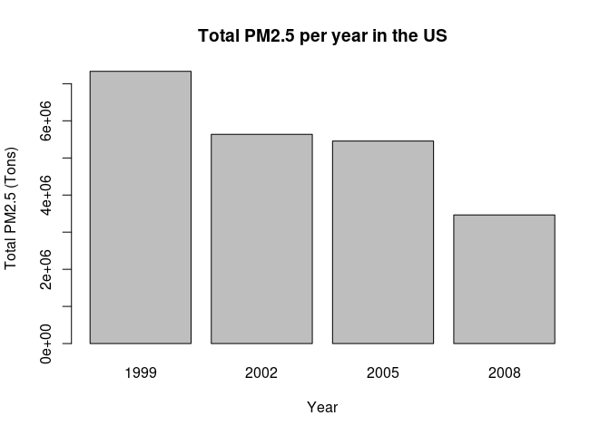

```r
years <- levels(as.factor(NEI$year))
totalpm25 <- sapply(years,function(x){
    temp <- subset(NEI, year == as.numeric(x) & Emissions > 0)
    sum(temp$Emissions)
})
barplot(totalpm25, names.arg = years, main = "Total PM2.5 per year in the US", ylab = "Total PM2.5 (Tons)", xlab = "Year" )
```

## Have total emissions from PM2.5 decreased in the Baltimore City, Maryland (fips == “24510”) from 1999 to 2008? Use the base plotting system to make a plot answering this question.

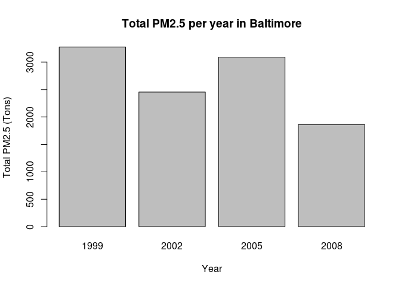

```r
years <- levels(as.factor(NEI$year))
baltpm25 <- sapply(years,function(x){
    temp <- subset(NEI, year == as.numeric(x) & Emissions > 0 & fips == "24510")
    sum(temp$Emissions)
})
barplot(baltpm25, names.arg = years, main = "Total PM2.5 per year in Baltimore", ylab = "Total PM2.5 (Tons)", xlab = "Year" )
```

## Of the four types of sources indicated by the type (point, nonpoint, onroad, nonroad) variable, which of these four sources have seen decreases in emissions from 1999–2008 for Baltimore City? Which have seen increases in emissions from 1999–2008? Use the ggplot2 plotting system to make a plot answer this question.

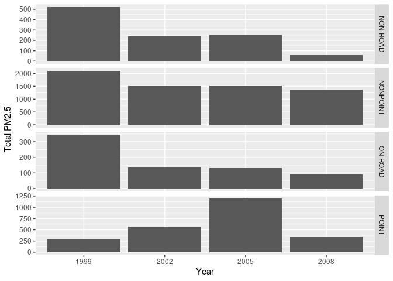

```r
library(ggplot2)
years <- levels(as.factor(NEI$year))
baltdata <- subset(NEI, fips == "24510" & Emissions >= 0)
type <- levels(as.factor(baltdata$type))
balttype <- data.frame(year = rep(as.numeric(years), each = 4), type = rep(type, times = 4))
total <- sapply(1:16, function(x){
    y <- as.numeric(balttype[x,1])
    t <- balttype[x,2]
    temp <- subset(baltdata, year == y & type == t)
    sum(temp$Emissions)
})
balttype$pm25 = total
ggplot(balttype, aes(x=factor(year), y= pm25)) + geom_bar(stat="identity") + facet_grid( type ~ ., scales = "free_y") + labs(x = "Year", y = "Total PM2.5")
```

## Across the United States, how have emissions from coal combustion-related sources changed from 1999–2008?

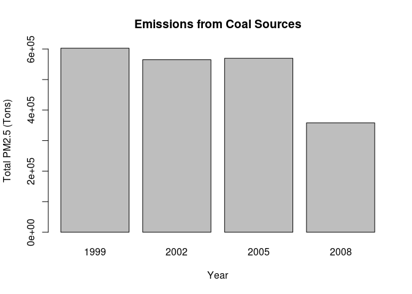

```r
years <- levels(as.factor(NEI$year))
coalsources <- SCC$SCC[grepl("[Cc]oal",as.character(SCC$Short.Name))]
sources <- as.character(coalsources)
coaldata <- subset(NEI, SCC %in% sources)
coalpm25 <- sapply(years,function(x){
    temp <- subset(coaldata, year == as.numeric(x) & Emissions > 0)
    sum(temp$Emissions)
})
barplot(coalpm25, names.arg = years, main = "Emissions from Coal Sources", ylab = "Total PM2.5 (Tons)", xlab = "Year")
```

## How have emissions from motor vehicle sources changed from 1999–2008 in Baltimore City?

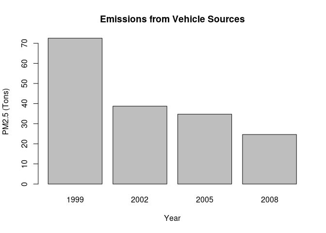

```r
years <- levels(as.factor(NEI$year))
vehiclesources <- SCC$SCC[grepl("[Vv]ehicle",as.character(SCC$Short.Name))]
sources <- as.character(vehiclesources)
baltvehicle <- subset(baltdata, SCC %in% sources)
baltcar <- sapply(years,function(x){
    temp <- subset(baltvehicle, year == as.numeric(x) & Emissions > 0)
    sum(temp$Emissions)
})
barplot(baltcar, names.arg = years, xlab = "Year", ylab = "PM2.5 (Tons)", main = "Emissions from Vehicle Sources")
```

## Compare emissions from motor vehicle sources in Baltimore City with emissions from motor vehicle sources in Los Angeles County, California (fips == “06037”). Which city has seen greater changes over time in motor vehicle emissions?

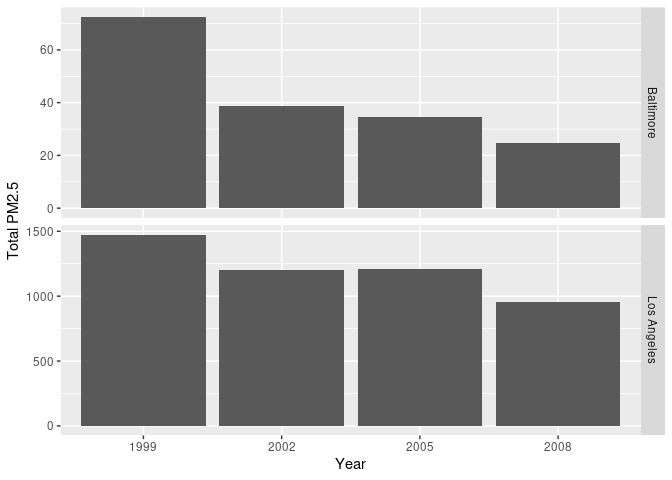

```r
years <- levels(as.factor(NEI$year))
city <- c("Baltimore","Los Angeles")
sources <- as.character(SCC$SCC[grepl("Vehicle",as.character(SCC$Short.Name))])
vehicledata <- subset(NEI, SCC %in% sources & fips %in% c("24510","06037"))
twocity <- data.frame(year = rep(as.numeric(years), times = 2), city = rep(city, each = 4))
citypm2 <- sapply(1:8, function(x){
    y <- as.numeric(twocity[x,1])
    f <- if(twocity[x,2] == "Baltimore"){
        as.factor("24510")}else {as.factor("06037")}
    temp <- subset(vehicledata, year == y & fips == f)
    sum(temp$Emissions)
})
twocity$pm25 = citypm2
ggplot(twocity, aes(x=factor(year), y= pm25)) + geom_bar(stat="identity") + facet_grid( city ~ ., scales ="free_y") + labs(x = "Year", y = "Total PM2.5")
```

```r
twocity
```

```
##   year        city       pm25
## 1 1999   Baltimore   72.52000
## 2 2002   Baltimore   38.72593
## 3 2005   Baltimore   34.73461
## 4 2008   Baltimore   24.62275
## 5 1999 Los Angeles 1474.39600
## 6 2002 Los Angeles 1202.22717
## 7 2005 Los Angeles 1206.40674
## 8 2008 Los Angeles  952.30448
```